# R Notebook

EXTRACCIÓN DE DATOS

Para comenzar, hemos trabajado esta parte de la práctica con datos extraídos de la web de datos abiertos de la Comunidad de Madrid, en concreto de los Accidentes de tráfico con implicación de bicicletas en 2018. Para ello, creamos las funciones y vemos el archivo (previamente instalamos y ejecutamos la librería “tidyverse”):

```r
View(AccidentesBicicletas_2018)
```

[output not shown]

Para saber el nombre de las columnas

```r
colnames(AccidentesBicicletas_2018)
```

```
 [1] "FECHA"              "RANGO HORARIO"      "DIA SEMANA"         "DISTRITO"
 [5] "LUGAR ACCIDENTE"    "Nº"                 "Nº PARTE"           "CPFA Granizo"
 [9] "CPFA Hielo"         "CPFA Lluvia"        "CPFA Niebla"        "CPFA Seco"
[13] "CPFA Nieve"         "CPSV Mojada"        "CPSV Aceite"        "CPSV Barro"
[17] "CPSV Grava Suelta"  "CPSV Hielo"         "CPSV Seca Y Limpia" "* Nº VICTIMAS"
[21] "TIPO ACCIDENTE"     "Tipo Vehiculo"      "TIPO PERSONA"       "SEXO"
[25] "LESIVIDAD"          "Tramo Edad"
```

Para saber el resumen de los datos

```r
str(AccidentesBicicletas_2018)
```

```
Classes ‘tbl_df’, ‘tbl’ and 'data.frame':   700 obs. of  26 variables:
 $ FECHA             : POSIXct, format: "2018-01-01" "2018-01-01" "2018-01-02" ...
 $ RANGO HORARIO     : chr  "DE 13:00 A 13:59" "DE 15:00 A 15:59" "DE 12:00 A 12:59" "DE 13:00 A 13:59" ...
 $ DIA SEMANA        : chr  "LUNES" "LUNES" "MARTES" "MIERCOLES" ...
 $ DISTRITO          : chr  "ARGANZUELA" "CENTRO" "SALAMANCA" "SALAMANCA" ...
 $ LUGAR ACCIDENTE   : chr  "CALLE DE ANCORA - PASEO DE LAS DELICIAS" "CALLE DE ALCALA NUM" "CALLE DE SERRANO - CALLE DEL CONDE DE ARANDA" "PLAZA DE LA INDEPENDENCIA NUM" ...
 $ Nº                : num  0 44 0 5 35 0 0 0 0 0 ...
 $ Nº PARTE          : chr  "2018/25" "2018/76" "2018/30" "2018/94" ...
 $ CPFA Granizo      : chr  "NO" "NO" "NO" "NO" ...
 $ CPFA Hielo        : chr  "NO" "NO" "NO" "NO" ...
 $ CPFA Lluvia       : chr  "NO" "NO" "NO" "NO" ...
 $ CPFA Niebla       : chr  "NO" "NO" "NO" "NO" ...
 $ CPFA Seco         : chr  "SI" "SI" "SI" "SI" ...
 $ CPFA Nieve        : chr  "NO" "NO" "NO" "NO" ...
 $ CPSV Mojada       : chr  "NO" "NO" "NO" "NO" ...
 $ CPSV Aceite       : chr  "NO" "NO" "NO" "NO" ...
 $ CPSV Barro        : chr  "NO" "NO" "NO" "NO" ...
 $ CPSV Grava Suelta : chr  "NO" "NO" "NO" "NO" ...
 $ CPSV Hielo        : chr  "NO" "NO" "NO" "NO" ...
 $ CPSV Seca Y Limpia: chr  "SI" "SI" "SI" "SI" ...
 $ * Nº VICTIMAS     : num  1 2 2 1 1 1 1 1 1 1 ...
 $ TIPO ACCIDENTE    : chr  "COLISIÓN DOBLE" "ATROPELLO" "ATROPELLO" "COLISIÓN DOBLE" ...
 $ Tipo Vehiculo     : chr  "BICICLETA" "BICICLETA" "BICICLETA" "BICICLETA" ...
 $ TIPO PERSONA      : chr  "CONDUCTOR" "CONDUCTOR" "CONDUCTOR" "CONDUCTOR" ...
 $ SEXO              : chr  "HOMBRE" "HOMBRE" "HOMBRE" "HOMBRE" ...
 $ LESIVIDAD         : chr  "HL" "HL" "HL" "HL" ...
 $ Tramo Edad        : chr  "DE 30 A 34 ANOS" "DE 25 A 29 AÑOS" "DE 40 A 44 AÑOS" "DE 50 A 54 AÑOS" ...
```

Hacemos una copia de la tabla original para trabajar con los datos

Elimninamos las columnas que creemos que no van a ser necesarias para el tratamiento de datos.

Con esta función dejamos la copia de la tabla con 12 variables

```r
colnames(accidente)
```

```
 [1] "FECHA"           "RANGO HORARIO"   "DIA SEMANA"      "DISTRITO"        "LUGAR ACCIDENTE"
 [6] "Nº PARTE"        "* Nº VICTIMAS"   "TIPO ACCIDENTE"  "Tipo Vehiculo"   "TIPO PERSONA"
[11] "SEXO"            "Tramo Edad"
```

Cambiamos el nombre a todas las columnas

Con la siguiente funcion obtenemos la gráfica y el número de hombres, mujeres y género no asigando que han tenido accidentes (pudiendo visualizar la consola de R y un diagrama de barras)

```r
fsexo = as.factor(accidente$Sexo)
fsexo
```

```
  [1] HOMBRE      HOMBRE      HOMBRE      HOMBRE      HOMBRE      HOMBRE      HOMBRE
  [8] HOMBRE      HOMBRE      HOMBRE      HOMBRE      HOMBRE      HOMBRE      MUJER
 [15] HOMBRE      HOMBRE      HOMBRE      HOMBRE      HOMBRE      MUJER       MUJER
 [22] HOMBRE      MUJER       HOMBRE      HOMBRE      HOMBRE      MUJER       HOMBRE
 [29] HOMBRE      HOMBRE      HOMBRE      MUJER       HOMBRE      HOMBRE      HOMBRE
 [36] HOMBRE      HOMBRE      HOMBRE      HOMBRE      HOMBRE      HOMBRE      HOMBRE
 [43] MUJER       HOMBRE      MUJER       HOMBRE      HOMBRE      HOMBRE      HOMBRE
 [50] MUJER       HOMBRE      HOMBRE      HOMBRE      MUJER       HOMBRE      HOMBRE
 [57] HOMBRE      HOMBRE      MUJER       HOMBRE      HOMBRE      MUJER       HOMBRE
 [64] MUJER       HOMBRE      HOMBRE      MUJER       HOMBRE      HOMBRE      HOMBRE
 [71] HOMBRE      HOMBRE      HOMBRE      HOMBRE      HOMBRE      MUJER       HOMBRE
 [78] HOMBRE      HOMBRE      HOMBRE      HOMBRE      HOMBRE      HOMBRE      HOMBRE
 [85] HOMBRE      HOMBRE      HOMBRE      HOMBRE      HOMBRE      MUJER       HOMBRE
 [92] HOMBRE      HOMBRE      MUJER       HOMBRE      MUJER       HOMBRE      HOMBRE
 [99] HOMBRE      MUJER       HOMBRE      MUJER       HOMBRE      MUJER       HOMBRE
```

[output cut: 86 more lines]

```r
levels(fsexo)
```

```
[1] "HOMBRE"      "MUJER"       "NO ASIGNADO"
```

```r
summary(fsexo)
```

```
     HOMBRE       MUJER NO ASIGNADO
        547         142          11
```

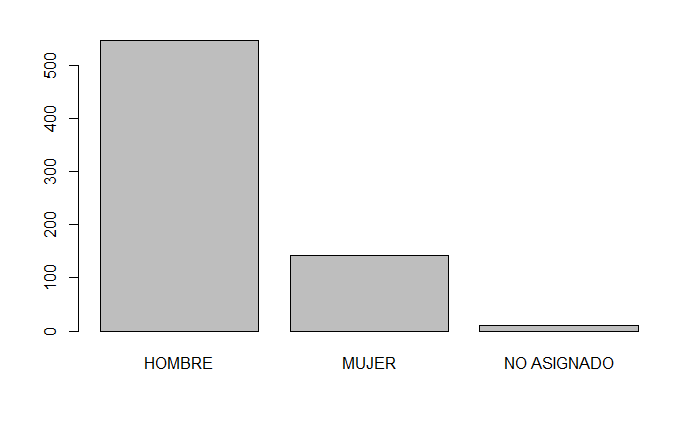

```r
plot(fsexo)
```

CON UN TOTAL DE 547 HOMBRES, 142 MUJERES Y UN TOTAL DE 11 NO ASIGNADOS

De la misma forma que en el caso anterior, con la siguiente función, hemos averiguado cuál es el rango horario con mayor número de accidentes de bicicleta.

```r
fhoras = as.factor(accidente$`Rango Horario`)
fhoras
```

```
  [1] DE 13:00 A 13:59 DE 15:00 A 15:59 DE 12:00 A 12:59 DE 13:00 A 13:59 DE 15:00 A 15:59
  [6] DE 22:00 A 22:59 DE 8:00 A 8:59   DE 9:00 A 9:59   DE 15:00 A 15:59 DE 20:00 A 20:59
 [11] DE 16:00 A 16:59 DE 16:00 A 16:59 DE 15:00 A 15:59 DE 14:00 A 14:59 DE 20:00 A 20:59
 [16] DE 11:00 A 11:59 DE 1:00 A 1:59   DE 9:00 A 9:59   DE 16:00 A 16:59 DE 16:00 A 16:59
 [21] DE 1:00 A 1:59   DE 15:00 A 15:59 DE 17:00 A 17:59 DE 21:00 A 21:59 DE 16:00 A 16:59
 [26] DE 8:00 A 8:59   DE 17:00 A 17:59 DE 12:00 A 12:59 DE 13:00 A 13:59 DE 13:00 A 13:59
 [31] DE 9:00 A 9:59   DE 19:00 A 19:59 DE 20:00 A 20:59 DE 20:00 A 20:59 DE 20:00 A 20:59
 [36] DE 21:00 A 21:59 DE 22:00 A 22:59 DE 15:00 A 15:59 DE 22:00 A 22:59 DE 9:00 A 9:59
 [41] DE 13:00 A 13:59 DE 15:00 A 15:59 DE 19:00 A 19:59 DE 12:00 A 12:59 DE 16:00 A 16:59
 [46] DE 16:00 A 16:59 DE 22:00 A 22:59 DE 15:00 A 15:59 DE 19:00 A 19:59 DE 21:00 A 21:59
 [51] DE 9:00 A 9:59   DE 13:00 A 13:59 DE 18:00 A 18:59 DE 8:00 A 8:59   DE 15:00 A 15:59
 [56] DE 19:00 A 19:59 DE 13:00 A 13:59 DE 19:00 A 19:59 DE 20:00 A 20:59 DE 5:00 A 5:59
 [61] DE 17:00 A 17:59 DE 9:00 A 9:59   DE 12:00 A 12:59 DE 17:00 A 17:59 DE 19:00 A 19:59
 [66] DE 18:00 A 18:59 DE 19:00 A 19:59 DE 12:00 A 12:59 DE 19:00 A 19:59 DE 13:00 A 13:59
 [71] DE 8:00 A 8:59   DE 2:00 A 2:59   DE 18:00 A 18:59 DE 21:00 A 21:59 DE 4:00 A 4:59
```

[output cut: 126 more lines]

```r
levels(fhoras)
```

```
 [1] "DE 00:00 A 00:59" "DE 1:00 A 1:59"   "DE 10:00 A 10:59" "DE 11:00 A 11:59"
 [5] "DE 12:00 A 12:59" "DE 13:00 A 13:59" "DE 14:00 A 14:59" "DE 15:00 A 15:59"
 [9] "DE 16:00 A 16:59" "DE 17:00 A 17:59" "DE 18:00 A 18:59" "DE 19:00 A 19:59"
[13] "DE 2:00 A 2:59"   "DE 20:00 A 20:59" "DE 21:00 A 21:59" "DE 22:00 A 22:59"
[17] "DE 23:00 A 23:59" "DE 3:00 A 3:59"   "DE 4:00 A 4:59"   "DE 5:00 A 5:59"
[21] "DE 6:00 A 6:59"   "DE 7:00 A 7:59"   "DE 8:00 A 8:59"   "DE 9:00 A 9:59"
```

```r
summary(fhoras)
```

```
DE 00:00 A 00:59   DE 1:00 A 1:59 DE 10:00 A 10:59 DE 11:00 A 11:59 DE 12:00 A 12:59
              16                9               34               38               41
DE 13:00 A 13:59 DE 14:00 A 14:59 DE 15:00 A 15:59 DE 16:00 A 16:59 DE 17:00 A 17:59
              53               39               47               45               27
DE 18:00 A 18:59 DE 19:00 A 19:59   DE 2:00 A 2:59 DE 20:00 A 20:59 DE 21:00 A 21:59
              50               60                7               40               45
DE 22:00 A 22:59 DE 23:00 A 23:59   DE 3:00 A 3:59   DE 4:00 A 4:59   DE 5:00 A 5:59
              30               13                5                5                5
  DE 6:00 A 6:59   DE 7:00 A 7:59   DE 8:00 A 8:59   DE 9:00 A 9:59
               3               16               26               46
```

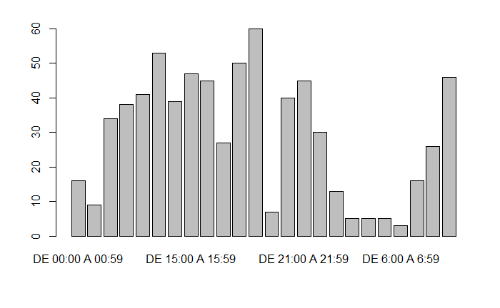

```r
plot(fhoras)
```

EL RANGO HORARIO CON MAYOR NUMERO DE ACCIDENTES ES DE 19:00 A 19:50

Calculamos el número medio y el número máximo de víctimas sobre todo el conjunto de accidente

```r
sapply(accidente[, 7], mean, na.rm = TRUE)
```

```
Numero Victimas
       1.127143
```

```r
sapply(accidente[, 7], max, na.rm = TRUE)
```

```
Numero Victimas
             15
```

Con esta funcion hemos cambiado el formato de la fecha a Dia, Mes y Año

```r
fecha <- accidente$Fecha
fecha
```

```
  [1] "2018-01-01 UTC" "2018-01-01 UTC" "2018-01-02 UTC" "2018-01-03 UTC" "2018-01-03 UTC"
  [6] "2018-01-03 UTC" "2018-01-04 UTC" "2018-01-04 UTC" "2018-01-04 UTC" "2018-01-04 UTC"
 [11] "2018-01-05 UTC" "2018-01-07 UTC" "2018-01-09 UTC" "2018-01-11 UTC" "2018-01-11 UTC"
 [16] "2018-01-12 UTC" "2018-01-13 UTC" "2018-01-15 UTC" "2018-01-15 UTC" "2018-01-16 UTC"
 [21] "2018-01-17 UTC" "2018-01-18 UTC" "2018-01-18 UTC" "2018-01-18 UTC" "2018-01-19 UTC"
 [26] "2018-01-20 UTC" "2018-01-20 UTC" "2018-01-21 UTC" "2018-01-21 UTC" "2018-01-22 UTC"
 [31] "2018-01-24 UTC" "2018-01-24 UTC" "2018-01-24 UTC" "2018-01-24 UTC" "2018-01-24 UTC"
 [36] "2018-01-24 UTC" "2018-01-24 UTC" "2018-01-26 UTC" "2018-01-26 UTC" "2018-01-27 UTC"
 [41] "2018-01-27 UTC" "2018-01-27 UTC" "2018-01-27 UTC" "2018-01-28 UTC" "2018-01-28 UTC"
 [46] "2018-01-28 UTC" "2018-01-28 UTC" "2018-01-29 UTC" "2018-01-29 UTC" "2018-01-29 UTC"
 [51] "2018-01-30 UTC" "2018-01-30 UTC" "2018-01-31 UTC" "2018-02-01 UTC" "2018-02-01 UTC"
 [56] "2018-02-01 UTC" "2018-02-02 UTC" "2018-02-02 UTC" "2018-02-02 UTC" "2018-02-04 UTC"
 [61] "2018-02-05 UTC" "2018-02-06 UTC" "2018-02-06 UTC" "2018-02-06 UTC" "2018-02-07 UTC"
 [66] "2018-02-08 UTC" "2018-02-08 UTC" "2018-02-09 UTC" "2018-02-10 UTC" "2018-02-12 UTC"
 [71] "2018-02-13 UTC" "2018-02-14 UTC" "2018-02-14 UTC" "2018-02-14 UTC" "2018-02-15 UTC"
```

[output cut: 125 more lines]

```r
format(fecha, format = "%d/%m/%y")
```

```
  [1] "01/01/18" "01/01/18" "02/01/18" "03/01/18" "03/01/18" "03/01/18" "04/01/18" "04/01/18"
  [9] "04/01/18" "04/01/18" "05/01/18" "07/01/18" "09/01/18" "11/01/18" "11/01/18" "12/01/18"
 [17] "13/01/18" "15/01/18" "15/01/18" "16/01/18" "17/01/18" "18/01/18" "18/01/18" "18/01/18"
 [25] "19/01/18" "20/01/18" "20/01/18" "21/01/18" "21/01/18" "22/01/18" "24/01/18" "24/01/18"
 [33] "24/01/18" "24/01/18" "24/01/18" "24/01/18" "24/01/18" "26/01/18" "26/01/18" "27/01/18"
 [41] "27/01/18" "27/01/18" "27/01/18" "28/01/18" "28/01/18" "28/01/18" "28/01/18" "29/01/18"
 [49] "29/01/18" "29/01/18" "30/01/18" "30/01/18" "31/01/18" "01/02/18" "01/02/18" "01/02/18"
 [57] "02/02/18" "02/02/18" "02/02/18" "04/02/18" "05/02/18" "06/02/18" "06/02/18" "06/02/18"
 [65] "07/02/18" "08/02/18" "08/02/18" "09/02/18" "10/02/18" "12/02/18" "13/02/18" "14/02/18"
 [73] "14/02/18" "14/02/18" "15/02/18" "15/02/18" "15/02/18" "16/02/18" "18/02/18" "18/02/18"
 [81] "19/02/18" "21/02/18" "21/02/18" "22/02/18" "22/02/18" "22/02/18" "23/02/18" "23/02/18"
 [89] "24/02/18" "24/02/18" "25/02/18" "25/02/18" "25/02/18" "26/02/18" "26/02/18" "27/02/18"
 [97] "28/02/18" "02/03/18" "02/03/18" "02/03/18" "03/03/18" "09/03/18" "09/03/18" "10/03/18"
[105] "11/03/18" "11/03/18" "11/03/18" "11/03/18" "12/03/18" "13/03/18" "13/03/18" "14/03/18"
[113] "14/03/18" "15/03/18" "16/03/18" "16/03/18" "16/03/18" "20/03/18" "21/03/18" "21/03/18"
```

[output cut: 73 more lines]

El formato antiguo que presenta la tabla de datos es : 2018-01-01 / Aplicando la fórmula mencionada arriba arriba los datos quedan representados así : “01/01/18”

Ahora organizamos la gráfica de accidentes/días de la semana correctamente de Lunes a Domingo, puesto que la original no llevaba un orden adecuado.

```r
# Realizamos la impresion de la grafica y nos damos cuenta de que estan desorganizados los dias de la semana
fdia = as.factor(accidente$`Dia Semana`)
fdia
```

```
  [1] LUNES     LUNES     MARTES    MIERCOLES MIERCOLES MIERCOLES JUEVES    JUEVES
  [9] JUEVES    JUEVES    VIERNES   DOMINGO   MARTES    JUEVES    JUEVES    VIERNES
 [17] SABADO    LUNES     LUNES     MARTES    MIERCOLES JUEVES    JUEVES    JUEVES
 [25] VIERNES   SABADO    SABADO    DOMINGO   DOMINGO   LUNES     MIERCOLES MIERCOLES
 [33] MIERCOLES MIERCOLES MIERCOLES MIERCOLES MIERCOLES VIERNES   VIERNES   SABADO
 [41] SABADO    SABADO    SABADO    DOMINGO   DOMINGO   DOMINGO   DOMINGO   LUNES
 [49] LUNES     LUNES     MARTES    MARTES    MIERCOLES JUEVES    JUEVES    JUEVES
 [57] VIERNES   VIERNES   VIERNES   DOMINGO   LUNES     MARTES    MARTES    MARTES
 [65] MIERCOLES JUEVES    JUEVES    VIERNES   SABADO    LUNES     MARTES    MIERCOLES
 [73] MIERCOLES MIERCOLES JUEVES    JUEVES    JUEVES    VIERNES   DOMINGO   DOMINGO
 [81] LUNES     MIERCOLES MIERCOLES JUEVES    JUEVES    JUEVES    VIERNES   VIERNES
 [89] SABADO    SABADO    DOMINGO   DOMINGO   DOMINGO   LUNES     LUNES     MARTES
 [97] MIERCOLES VIERNES   VIERNES   VIERNES   SABADO    VIERNES   VIERNES   SABADO
[105] DOMINGO   DOMINGO   DOMINGO   DOMINGO   LUNES     MARTES    MARTES    MIERCOLES
[113] MIERCOLES JUEVES    VIERNES   VIERNES   VIERNES   MARTES    MIERCOLES MIERCOLES
```

[output cut: 74 more lines]

```r
levels(fdia)
```

```
[1] "DOMINGO"   "JUEVES"    "LUNES"     "MARTES"    "MIERCOLES" "SABADO"    "VIERNES"
```

```r
summary(fdia)
```

```
  DOMINGO    JUEVES     LUNES    MARTES MIERCOLES    SABADO   VIERNES
       86       117        91       106       100        99       101
```

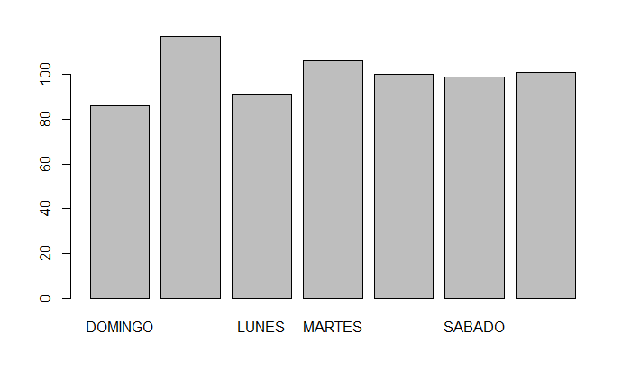

```r
plot(fdia)
```

```r
# Para poder organizar los datos necesitamos cambiar a factor la variable:

fechas2 <- as.factor(accidente$`Dia Semana`)
# ver como está ordenada
levels(fechas2)
```

```
[1] "DOMINGO"   "JUEVES"    "LUNES"     "MARTES"    "MIERCOLES" "SABADO"    "VIERNES"
```

```r
# confirmar que tiene 7 niveles
nlevels(fechas2)
```

```
[1] 7
```

```r
summary(fechas2)
```

```
  DOMINGO    JUEVES     LUNES    MARTES MIERCOLES    SABADO   VIERNES
       86       117        91       106       100        99       101
```

```r
# ordenar correctamente
fechas2 = factor(accidente$`Dia Semana`, levels = c("LUNES", "MARTES", "MIERCOLES", "JUEVES", "VIERNES", "SABADO", "DOMINGO"))
# confirmar que está ordenada
levels(fechas2)
```

```
[1] "LUNES"     "MARTES"    "MIERCOLES" "JUEVES"    "VIERNES"   "SABADO"    "DOMINGO"
```

```r
summary(fechas2)
```

```
    LUNES    MARTES MIERCOLES    JUEVES   VIERNES    SABADO   DOMINGO
       91       106       100       117       101        99        86
```

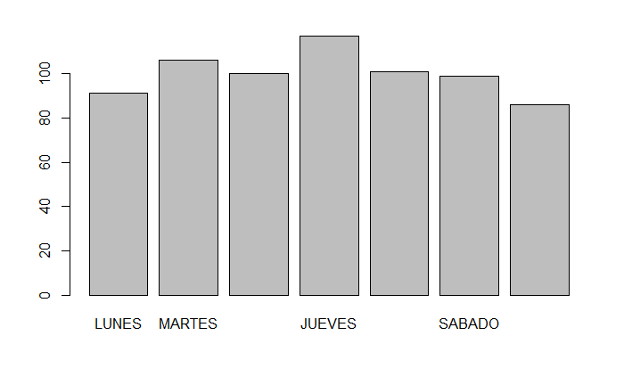

```r
plot(fechas2)
```